# Consulting

```r
library(mosaic)
library(car)
library(DT)
library(pander)
library(readr)
library(tidyverse)
library(plotly)
soecol <- read_csv("soecol.csv")
```

## Intro/Context

The data set used for this analysis contains sales information (# of units sold) by week and by month of the company SOECOL. They have been struggling with the number of employees that they hire every season because they don’t know for sure what should be the average # of employees that they should hire every month in order to make sure that they can produce enough products to satisfy the sales orders. This analysis is to see which months will require higher # of employees. The hypotheses for this analysis are shown below

## Ho/Ha (ANOVA)

The null hypotheses assumes that the average number of units sold every month is equal and don’t different from each other. We will take a closer ook at the result to analyze what are the month when the company needs to hire more employees.

$$H_0: \mu \text {Jan} = \mu \text{Feb} = \mu \text{Mar} = \mu
\text{Apr} = \mu \text{May} = \mu \text{Jun} = \mu \text{Jul} = \mu
\text{Aug} = \mu \text{Sep} = \mu \text{Oct} = \mu \text{Nov} = \mu
\text{Dec} = \mu$$

$$H_a: \mu_i \neq \mu$$

$$α=0.05$$

## Graphical Summary

This graph shows the data of units sold grouped by month. We can see a peak that in month 9/September it seems that they sell more units, however, we will proceed to perform an ANOVA test to determine more precisely if we reject or fail to reject the null hypotheses to be able to come up with a conclusion.

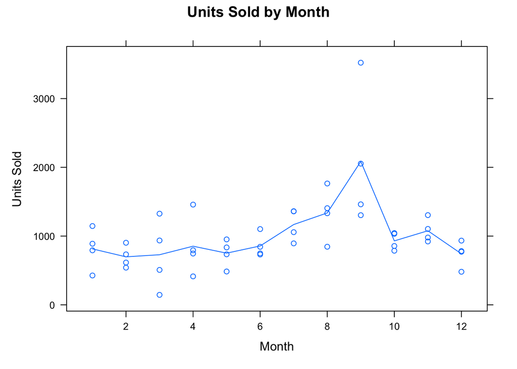

```r
xyplot(Units ~ Month, data=soecol, main="Units Sold by Month", ylab="Units Sold", xlab="Month", type=c("p","a"))
```

## Numerical Summary

```r
favstats(Units ~ Month, data = soecol) |>
pander()
```

| Month | min | Q1 | median | Q3 | max | mean | sd | n | missing |
| --- | --- | --- | --- | --- | --- | --- | --- | --- | --- |
| 1 | 427 | 701.5 | 841 | 953.2 | 1146 | 813.8 | 297.8 | 4 | 0 |
| 2 | 541 | 596.5 | 674.5 | 776.2 | 903 | 698.2 | 158 | 4 | 0 |
| 3 | 145 | 417.2 | 722 | 1034 | 1326 | 728.8 | 512.9 | 4 | 0 |
| 4 | 414 | 663 | 770 | 960 | 1458 | 853 | 437.3 | 4 | 0 |
| 5 | 485 | 672.5 | 785 | 864.2 | 952 | 751.8 | 198.7 | 4 | 0 |
| 6 | 732 | 744 | 796 | 908.5 | 1102 | 856.5 | 171 | 4 | 0 |
| 7 | 894 | 1016 | 1208 | 1360 | 1362 | 1168 | 232 | 4 | 0 |
| 8 | 845 | 1210 | 1369 | 1496 | 1765 | 1337 | 378.6 | 4 | 0 |
| 9 | 1304 | 1422 | 1758 | 2421 | 3522 | 2086 | 1011 | 4 | 0 |
| 10 | 787 | 838.8 | 944.5 | 1036 | 1044 | 930 | 128.5 | 4 | 0 |
| 11 | 922 | 964.8 | 1042 | 1154 | 1305 | 1078 | 169.6 | 4 | 0 |
| 12 | 481 | 699.2 | 777 | 820 | 934 | 742.2 | 189.3 | 4 | 0 |

## ANOVA Test

```r
soecol.aov <- aov(Units ~ as.factor(Month), data = soecol)
  pander(summary(soecol.aov))
```

Analysis of Variance Model

|  | Df | Sum Sq | Mean Sq | F value | Pr(>F) |
| --- | --- | --- | --- | --- | --- |
| **as.factor(Month)** | 11 | 6801775 | 618343 | 3.832 | 0.001071 |
| **Residuals** | 36 | 5808837 | 161357 | NA | NA |

## Check the Requirements

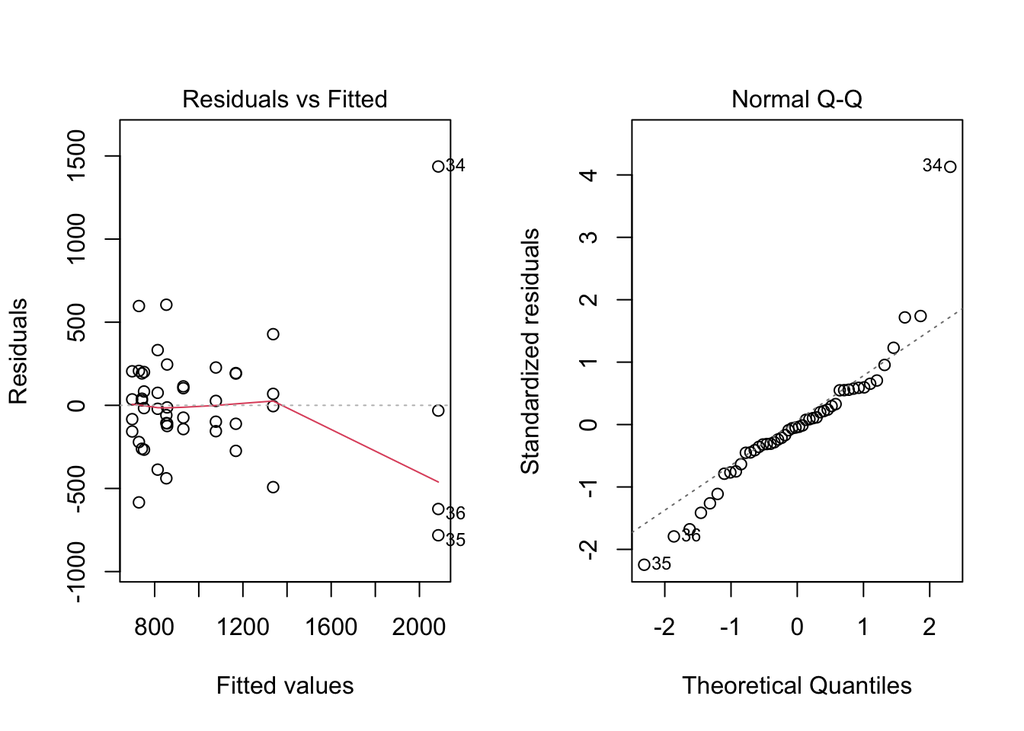

```r
par(mfrow=c(1,2))
plot(soecol.aov, which= 1:2)
```

These two graph show the Residual vs Fitted on the left and the Normal Q-Q plot on the right. We can see that there are some outliers as shown in both graphs, and it’s because of these inconsistencies that a non-parametric test like Kruskal-Wallis would be more appropriate for this analysis. (The ouliers are in values 34, 35, and 36)

## Kruskal-Wallis Rank Sum Test

Since the requirements have not been met for an ANOVA test, we are moving forward and conducting a Kruskal-Wallis Rank Sum Test as follows

```r
pander(kruskal.test(Units ~ as.factor(Month), data = soecol))
```

Kruskal-Wallis rank sum test: `Units` by `as.factor(Month)`

| Test statistic | df | P value |
| --- | --- | --- |
| 23.58 | 11 | 0.01462 * |

Based on the results after performing a Kruskal-Wallis type of test, we see that the p-value for this tests is p-value = 0.01462, which is lower than the significance level of 0.05. Based on this p-value results we can say that under the Kruskal-Walling conditions, we still reject the null hypotheses and accept the alternative which is the same results and conclusion of the ANOVA. However, the p-values for the ANOVA and Kruskal-Wallis are different.

## Conclusion/Future Studies

```r
soecol |>
    group_by(Month) |>
   summarise(Units_Average = mean(Units)) |>
  pander()
```

| Month | Units_Average |
| --- | --- |
| 1 | 813.8 |
| 2 | 698.2 |
| 3 | 728.8 |
| 4 | 853 |
| 5 | 751.8 |
| 6 | 856.5 |
| 7 | 1168 |
| 8 | 1337 |
| 9 | 2086 |
| 10 | 930 |
| 11 | 1078 |
| 12 | 742.2 |

For future studies, the sample size of each group should be greater than 30. In that way we can fulfill the requirements of the anova tests and have a more consistent and large data set to analyze in more depth the hypotheses used for this analysis.